# Part II - Prosper Loan Data

## by Fedi Haddadi

## Investigation Overview

> We are looking to discover the key factors affecting The estimated Return and the recurrent patterns between the variables of interest

## Dataset Overview

> This dataset contains data of approximately 114,00.0 loans with 81 features (including loan amount, borrower rate (or interest rate), current loan status, borrower income, Investors...)

## Number of investors across the Loan ammounts and the Estimated Return rates

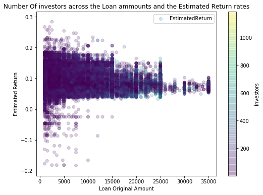

> We want to explore how the number of investors changes depends on the Loan ammounts and the Estimated Return rates.

> We see that the number of investor increases in the loans of amounts between 20000 and 25000. The number of investors is low in high Return Loans (>20%)

## Borrower APR Relation with Prosper Rating and Loan Term

> We want to explore how the Borrower APR changes across the Prosper ratingsand the Loan term length.

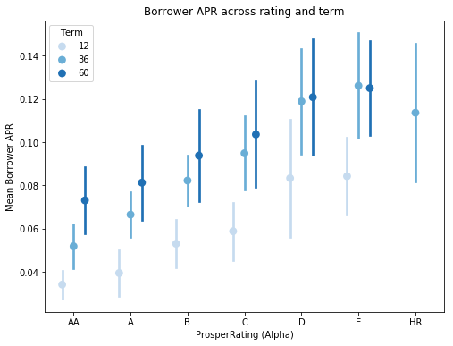

## Loan Preferences Across Employment Status

We will explore the preferences of loans in term length and Prosper rating, and also the estimated return distribution accross the emplyment statuses.

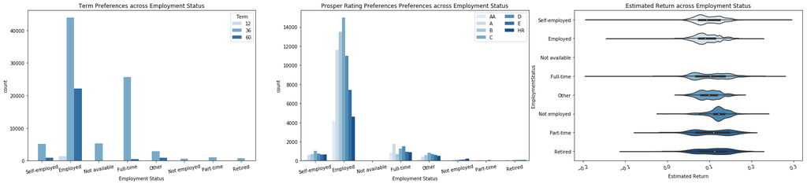

> The C rated Loans are the the most popular among the employed, self employed. For the full time, it will be the A rated loans.